# TD1

## Exercice 1

1. Create a vector of number
   - The list from 1 to 100

[output not shown]

````
```
  [1]   1   2   3   4   5   6   7   8   9  10  11  12  13  14  15
 [16]  16  17  18  19  20  21  22  23  24  25  26  27  28  29  30
 [31]  31  32  33  34  35  36  37  38  39  40  41  42  43  44  45
 [46]  46  47  48  49  50  51  52  53  54  55  56  57  58  59  60
 [61]  61  62  63  64  65  66  67  68  69  70  71  72  73  74  75
 [76]  76  77  78  79  80  81  82  83  84  85  86  87  88  89  90
 [91]  91  92  93  94  95  96  97  98  99 100
```
````

- A number list/sequence for 10, 20, 25, 50, repeated 5 times ( 10 20 25 50 10 20 25 50 10 20 25 50 10 20 25 50 10 20 25 50)

````
```r
rep(c(10,20,25,50),5)
```
````

```
- a list from 1 to 100, with a step of 5
```

````
```r
seq(1,100,5)
```
````

```
- Repeat 10 times the number 12
```

````
```r
rep(12,10)
```
````

2. A vector with the number 1, 2, 3 with a repetition of each 4 times with in addition a repetition of the sequence of 4 times
   - Put this vector in the object « VEC »

````
```r
VEC = rep(c(1,2,3),each = 4, times = 4)
VEC
```
````

```
- Multiply all the element of VEC by 5
```

````
```r
VEC = VEC * 5
VEC
```
````

```
- Calculate the median and the quantile of 75%
```

````
```r
quantile(VEC, 0.5) # Median
quantile(VEC, 0.75)
```
````

3. Create a vector with a serie of number from 1 to 2000 with a step of 10
   - Put it in the object « vec »

[output not shown]

````
```
  [1]    1   11   21   31   41   51   61   71   81   91  101  111
 [13]  121  131  141  151  161  171  181  191  201  211  221  231
 [25]  241  251  261  271  281  291  301  311  321  331  341  351
 [37]  361  371  381  391  401  411  421  431  441  451  461  471
 [49]  481  491  501  511  521  531  541  551  561  571  581  591
 [61]  601  611  621  631  641  651  661  671  681  691  701  711
 [73]  721  731  741  751  761  771  781  791  801  811  821  831
 [85]  841  851  861  871  881  891  901  911  921  931  941  951
 [97]  961  971  981  991 1001 1011 1021 1031 1041 1051 1061 1071
[109] 1081 1091 1101 1111 1121 1131 1141 1151 1161 1171 1181 1191
[121] 1201 1211 1221 1231 1241 1251 1261 1271 1281 1291 1301 1311
[133] 1321 1331 1341 1351 1361 1371 1381 1391 1401 1411 1421 1431
[145] 1441 1451 1461 1471 1481 1491 1501 1511 1521 1531 1541 1551
[157] 1561 1571 1581 1591 1601 1611 1621 1631 1641 1651 1661 1671
[169] 1681 1691 1701 1711 1721 1731 1741 1751 1761 1771 1781 1791
[181] 1801 1811 1821 1831 1841 1851 1861 1871 1881 1891 1901 1911
[193] 1921 1931 1941 1951 1961 1971 1981 1991
```
````

```
- Extract the 10 th value of vec
```

````
```r
vec[10]
```
````

```
- Display a sub-vector called « vec2 » that corresponds to the values from 2 to 6
```

[output not shown]

````
```
[1] 11 21 31 41 51
```
````

```
- Replace the last value of vec2 by 100
```

[output not shown]

````
```
[1]  11  21  31  41 100
```
````

```
- Display vec2 without its 3th value and store it in vec3
```

[output not shown]

````
```
[1]  11  21  41 100
```
````

```
- Replace all the values >= 30 by 30
```

[output not shown]

````
```
[1] 11 21 30 30
```
````

## Exercice 2 : Opérations avec les tables

Create a matric with 5 columns and 20 lines with the values from 1 to 100, by lines - Call it MAT

```r
MAT = matrix(1:100,byrow = TRUE, ncol = 5)
MAT
```

```
      [,1] [,2] [,3] [,4] [,5]
 [1,]    1    2    3    4    5
 [2,]    6    7    8    9   10
 [3,]   11   12   13   14   15
 [4,]   16   17   18   19   20
 [5,]   21   22   23   24   25
 [6,]   26   27   28   29   30
 [7,]   31   32   33   34   35
 [8,]   36   37   38   39   40
 [9,]   41   42   43   44   45
[10,]   46   47   48   49   50
[11,]   51   52   53   54   55
[12,]   56   57   58   59   60
[13,]   61   62   63   64   65
[14,]   66   67   68   69   70
[15,]   71   72   73   74   75
[16,]   76   77   78   79   80
[17,]   81   82   83   84   85
[18,]   86   87   88   89   90
[19,]   91   92   93   94   95
[20,]   96   97   98   99  100
```

- Display the value at the second line and 5 th column et replace it by NA

```r
MAT[2,5] = NA
MAT
```

```
      [,1] [,2] [,3] [,4] [,5]
 [1,]    1    2    3    4    5
 [2,]    6    7    8    9   NA
 [3,]   11   12   13   14   15
 [4,]   16   17   18   19   20
 [5,]   21   22   23   24   25
 [6,]   26   27   28   29   30
 [7,]   31   32   33   34   35
 [8,]   36   37   38   39   40
 [9,]   41   42   43   44   45
[10,]   46   47   48   49   50
[11,]   51   52   53   54   55
[12,]   56   57   58   59   60
[13,]   61   62   63   64   65
[14,]   66   67   68   69   70
[15,]   71   72   73   74   75
[16,]   76   77   78   79   80
[17,]   81   82   83   84   85
[18,]   86   87   88   89   90
[19,]   91   92   93   94   95
[20,]   96   97   98   99  100
```

- Create “mat “ with only the columns 2,3 and 4 (taking them from MAT)

```r
mat = MAT[,2:4]
mat
```

```
      [,1] [,2] [,3]
 [1,]    2    3    4
 [2,]    7    8    9
 [3,]   12   13   14
 [4,]   17   18   19
 [5,]   22   23   24
 [6,]   27   28   29
 [7,]   32   33   34
 [8,]   37   38   39
 [9,]   42   43   44
[10,]   47   48   49
[11,]   52   53   54
[12,]   57   58   59
[13,]   62   63   64
[14,]   67   68   69
[15,]   72   73   74
[16,]   77   78   79
[17,]   82   83   84
[18,]   87   88   89
[19,]   92   93   94
[20,]   97   98   99
```

```r
mat[mat>40 && mat<60] = 50
mat
```

```
      [,1] [,2] [,3]
 [1,]    2    3    4
 [2,]    7    8    9
 [3,]   12   13   14
 [4,]   17   18   19
 [5,]   22   23   24
 [6,]   27   28   29
 [7,]   32   33   34
 [8,]   37   38   39
 [9,]   42   43   44
[10,]   47   48   49
[11,]   52   53   54
[12,]   57   58   59
[13,]   62   63   64
[14,]   67   68   69
[15,]   72   73   74
[16,]   77   78   79
[17,]   82   83   84
[18,]   87   88   89
[19,]   92   93   94
[20,]   97   98   99
```

## Exercise 3. Operations with a table of decimal numbers

1. Get the file (moodle) M&Ms.xls and open it with excel or open-office
- save it as MetMs.txt
- Import it in R and store it in data

```r
library(readxl)
data <- read_excel("~/Téléchargements/MetMs.xlsx")
```

```r
data2 = subset(data, select = -Forme)
data2 = na.omit(data2)
data2
```

| Indice | Couleur | Longueur maximale (mm) | Poids (g) |
| --- | --- | --- | --- |
| 1 | Orange | 17.4 | 2.0 |
| 2 | Bleu | 20.9 | 2.4 |
| 3 | Vert | 15.1 | 1.9 |
| 4 | Jaune | 15.4 | 2.0 |
| 5 | Bleu | 15.6 | 1.7 |
| 6 | Marron | 17.6 | 2.9 |
| 7 | Marron | 14.2 | 1.7 |
| 8 | Bleu | 15.7 | 2.3 |
| 9 | Marron | 17.3 | 2.4 |
| 10 | Jaune | 16.9 | 2.5 |

[output cut: 90 more lines]

- Determine for which colors the lengths are minimal and maximal

```r
with(data2, Couleur[`Longueur maximale (mm)` == min(`Longueur maximale (mm)`)])
```

```
[1] "Bleu"
```

```r
with(data2, Couleur[`Longueur maximale (mm)` == max(`Longueur maximale (mm)`)])
```

```
[1] "Rouge"
```

- Sort the lines of data2 according to an increasing order of the length

```r
data2[order(data2$`Longueur maximale (mm)`),]
```

| Indice | Couleur | Longueur maximale (mm) | Poids (g) |
| --- | --- | --- | --- |
| 13 | Bleu | 12.8 | 1.2 |
| 99 | Bleu | 13.4 | 1.2 |
| 60 | Vert | 13.7 | 1.7 |
| 67 | Jaune | 14.0 | 1.5 |
| 7 | Marron | 14.2 | 1.7 |
| 87 | Vert | 14.5 | 1.6 |
| 93 | Orange | 14.5 | 1.8 |
| 11 | Rouge | 14.6 | 1.9 |
| 97 | Bleu | 14.9 | 1.7 |
| 92 | Orange | 15.0 | 1.9 |

[output cut: 90 more lines]

## Exercice 4. Graphics

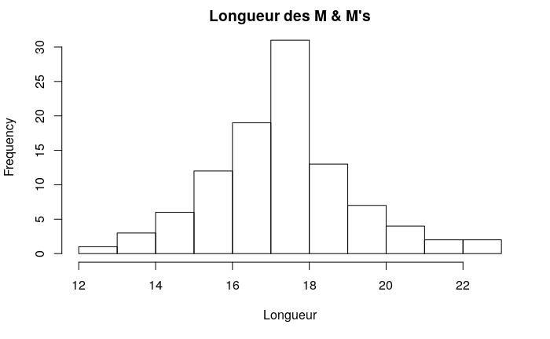

```r
hist(data2$`Longueur maximale (mm)`, xlab = "Longueur", main = "Longueur des M & M's")
```

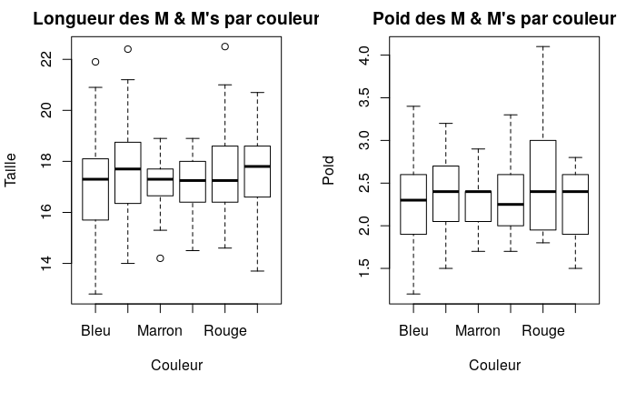

```r
par(mfrow=c(1,2))
boxplot(data = data2,`Longueur maximale (mm)`~ Couleur , main = "Longueur des M & M's par couleur", xlab= "Couleur", ylab= "Taille")
boxplot(data = data2,`Poids (g)`~ Couleur , main = "Poid des M & M's par couleur", xlab= "Couleur", ylab= "Poid")
```